# **Location-scale Meta-analysis and Meta-regression as a Tool to Capture Large-scale Changes in Biological and Methodological Heterogeneity: a Spotlight on Heteroscedasticity**

The `Rhat` indicates the model fit is much better than the earlier one, though the effective sample sizes of the scale part are still not high:

```r
fit_ma4 <- readRDS(here("Rdata", "fit_ma4.rds"))
summary(fit_ma4)
##  Family: gaussian
##   Links: mu = identity; sigma = log
## Formula: smd ~ 1 + (1 | study_ID) + (1 | gr(es_ID, cov = vcv))
##          sigma ~ 1 + (1 | study_ID)
##    Data: dat (Number of observations: 98)
##   Draws: 2 chains, each with iter = 30000; warmup = 5000; thin = 1;
##          total post-warmup draws = 50000
##
## Multilevel Hyperparameters:
## ~es_ID (Number of levels: 98)
##               Estimate Est.Error l-95% CI u-95% CI Rhat Bulk_ESS Tail_ESS
## sd(Intercept)     1.00      0.00     1.00     1.00   NA       NA       NA
##
## ~study_ID (Number of levels: 40)
##                     Estimate Est.Error l-95% CI u-95% CI Rhat Bulk_ESS Tail_ESS
## sd(Intercept)           0.66      0.15     0.41     0.98 1.00     2164      816
## sd(sigma_Intercept)     1.53      0.51     0.72     2.72 1.02      387      277
##
## Regression Coefficients:
##                 Estimate Est.Error l-95% CI u-95% CI Rhat Bulk_ESS Tail_ESS
## Intercept          -0.46      0.15    -0.77    -0.17 1.00     2895     5918
## sigma_Intercept    -1.40      0.66    -2.97    -0.40 1.02      374      189
##
## Draws were sampled using sampling(NUTS). For each parameter, Bulk_ESS
## and Tail_ESS are effective sample size measures, and Rhat is the potential
## scale reduction factor on split chains (at convergence, Rhat = 1).
```

While each chain indeed convergences, chains 1 and 2 performed slightly differently:

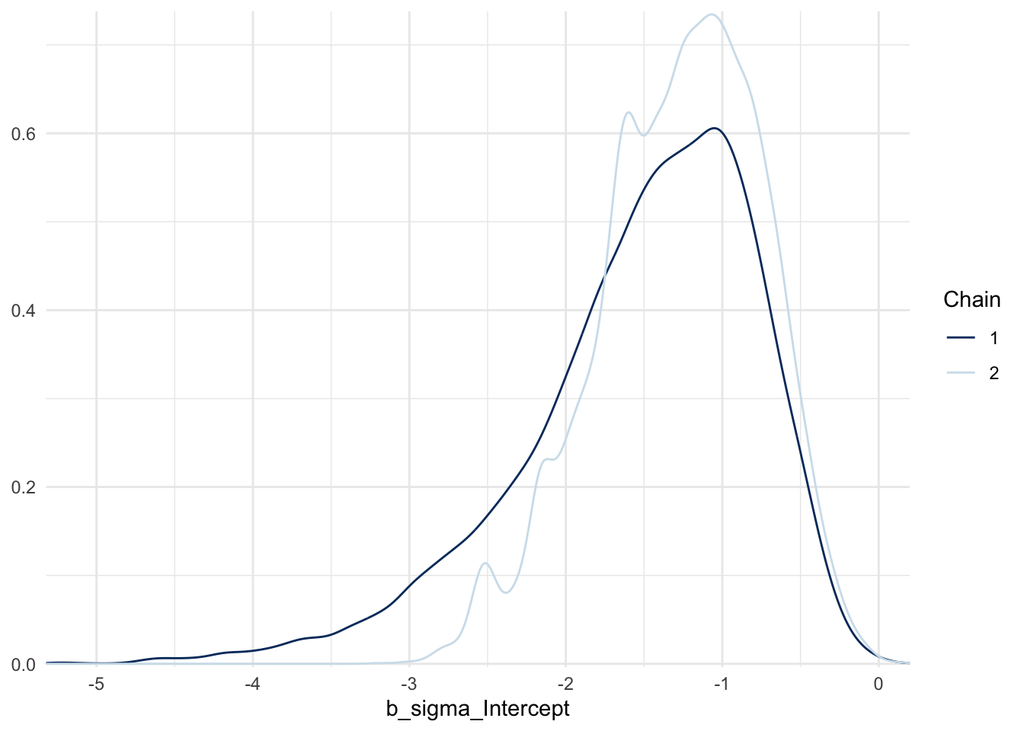

```r
draws <- as_draws_df(fit_ma4)
draws %>%
  mutate(chain = .chain) %>%
  bayesplot::mcmc_dens_overlay(pars = vars(b_sigma_Intercept)) +
  theme_minimal()
```

The scale part still has a high autocorrelation, leading to the low effective sample sizes:

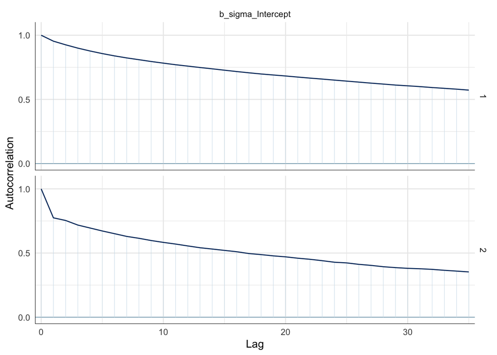

```r
draws %>%
  mutate(chain = .chain) %>%
  mcmc_acf(pars = vars(b_sigma_Intercept), lags = 35) +
  theme_minimal()
```

In these case, it is probably advisable not to have the between-study random effect in the scale part.

### 7.3.3 Test publication bias based on multilevel location-scale meta-regression

Given the model convergence issues shown above, we decide to test publication bias without including random effects in the scale part (Equations (35) and (36)). Below, we will illustrate it using both `brms` and `lsmeta`. The results from the two packages converge very well.

#### 7.3.3.1 `brms`

Testing publication bias is essence fitting a location-scale meta-regression with `se` and `cyear` as the moderators of both the location and scale parts. If you followed the previous instructions well, you’ll be well aware that to fit a location-scale meta-regression using `brms`, we need to specify the model structure and prior, and fit the specified model:

```r
form_mr4 <- bf(smd
             ~ 1  + se + cyear +
               (1|study_ID) + # this is u
               (1|gr(es_ID, cov = vcv)), # this is m
             sigma ~ 1 + se + cyear
)

prior_mr4 <- default_prior(form_mr4,
                         data = dat,
                         data2 = list(vcv = vcv),
                         family = gaussian()
)

# fixing the variance to 1 (meta-analysis)
prior_mr4$prior[8] = "constant(1)"
prior_mr4
# fit model

fit_mr4 <- brm(form_mr4,
             data = dat,
             data2 = list(vcv = vcv),
             chains = 2,
             cores = 2,
             iter =35000,
             warmup = 5000,
             #backend = "cmdstanr",
             prior = prior_mr4,
             #threads = threading(9),
             control = list(adapt_delta = 0.99, max_treedepth = 15)
)

# save this as rds
saveRDS(fit_mr4, here("Rdata", "fit_mr4.rds"))
```

The results indicate that while we do not find the small-study effect and the decline effect, there is evidence for small-study divergence and Proteus effect:

```r
fit_mr4 <- readRDS(here("Rdata", "fit_mr4.rds"))
summary(fit_mr4)
##  Family: gaussian
##   Links: mu = identity; sigma = log
## Formula: smd ~ 1 + cyear + se + (1 | study_ID) + (1 | gr(es_ID, cov = vcv))
##          sigma ~ 1 + cyear + se
##    Data: dat (Number of observations: 98)
##   Draws: 2 chains, each with iter = 35000; warmup = 5000; thin = 1;
##          total post-warmup draws = 60000
##
## Multilevel Hyperparameters:
## ~es_ID (Number of levels: 98)
##               Estimate Est.Error l-95% CI u-95% CI Rhat Bulk_ESS Tail_ESS
## sd(Intercept)     1.00      0.00     1.00     1.00   NA       NA       NA
##
## ~study_ID (Number of levels: 40)
##               Estimate Est.Error l-95% CI u-95% CI Rhat Bulk_ESS Tail_ESS
## sd(Intercept)     0.66      0.13     0.44     0.95 1.00    15622    27363
##
## Regression Coefficients:
##                 Estimate Est.Error l-95% CI u-95% CI Rhat Bulk_ESS Tail_ESS
## Intercept           0.10      0.33    -0.53     0.75 1.00    19025    27181
## sigma_Intercept    -2.30      0.61    -3.59    -1.19 1.00     1933     2693
## cyear              -0.04      0.04    -0.12     0.04 1.00    28664    36930
## se                 -0.89      0.58    -2.06     0.23 1.00    15695    22795
## sigma_cyear        -0.19      0.06    -0.31    -0.09 1.00     1317     1709
## sigma_se            2.13      0.67     0.74     3.41 1.00     4982     6298
##
## Draws were sampled using sampling(NUTS). For each parameter, Bulk_ESS
## and Tail_ESS are effective sample size measures, and Rhat is the potential
## scale reduction factor on split chains (at convergence, Rhat = 1).
```

Visualizations also indicates what we found above:

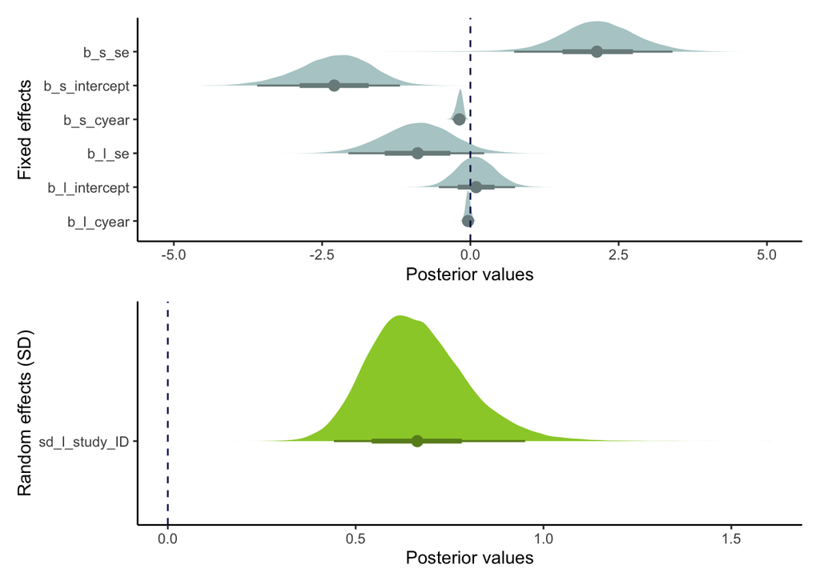

```r
# getting plots
plots_fit_mr4 <- list(
  visualize_fixed_effects(fit_mr4),
  visualize_random_effects(fit_mr4)
)


plots_fit_mr4[[1]] / plots_fit_mr4[[2]]
```

We notice actually `se` is significant from the `metafor` model (i.e., we have a small-study effect). This is because the results from `metafor` which ignores the scale part are distinct from those from `brms` and `blsmeta`. This leads to an interesting point that without modeling the scale part, the model detected an incorrect, small-study effect (probably, due to the small-study divergence was creating the small-study effect).

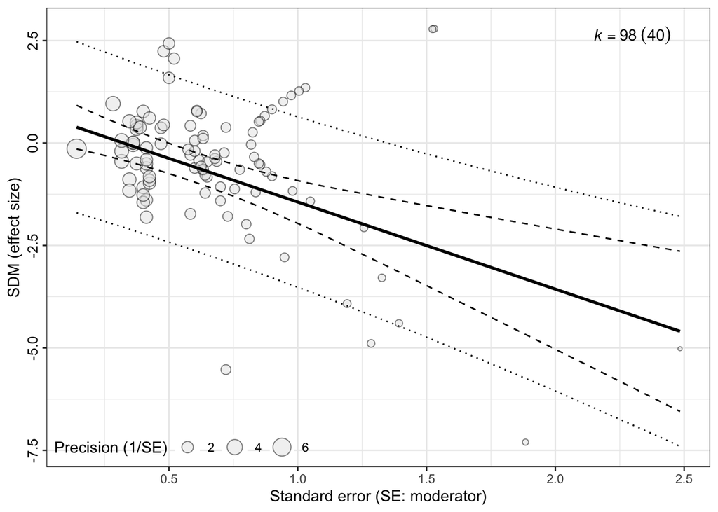

```r
mr4_mod <- rma.mv(yi = smd,
                  V =  vcv,
                  mod = ~ se + cyear,
                  random = list(~1 | study_ID,
                                ~1 | es_ID),
                  data = dat,
                  test = "t",
                  sparse = TRUE,
                  control=list(optimizer="optim", optmethod="Nelder-Mead")
)

summary(mr4_mod)
##
## Multivariate Meta-Analysis Model (k = 98; method: REML)
##
##    logLik   Deviance        AIC        BIC       AICc
## -149.7364   299.4729   309.4729   322.2423   310.1471
##
## Variance Components:
##
##             estim    sqrt  nlvls  fixed    factor
## sigma^2.1  0.6034  0.7768     40     no  study_ID
## sigma^2.2  0.4230  0.6504     98     no     es_ID
##
## Test for Residual Heterogeneity:
## QE(df = 95) = 368.7185, p-val < .0001
##
## Test of Moderators (coefficients 2:3):
## F(df1 = 2, df2 = 95) = 8.6002, p-val = 0.0004
##
## Model Results:
##
##          estimate      se     tval  df    pval    ci.lb    ci.ub
## intrcpt    0.6862  0.3455   1.9860  95  0.0499   0.0003   1.3721    *
## se        -2.1265  0.5128  -4.1469  95  <.0001  -3.1445  -1.1085  ***
## cyear      0.0010  0.0383   0.0264  95  0.9790  -0.0751   0.0771
##
## ---
## Signif. codes:  0 '***' 0.001 '**' 0.01 '*' 0.05 '.' 0.1 ' ' 1

bubble_plot(mr4_mod, mod = "se", group = "study_ID", g = TRUE,
            xlab = "Standard error (SE: moderator)",
            ylab = "SDM (effect size)",
            legend.pos = "bottom.left")
```

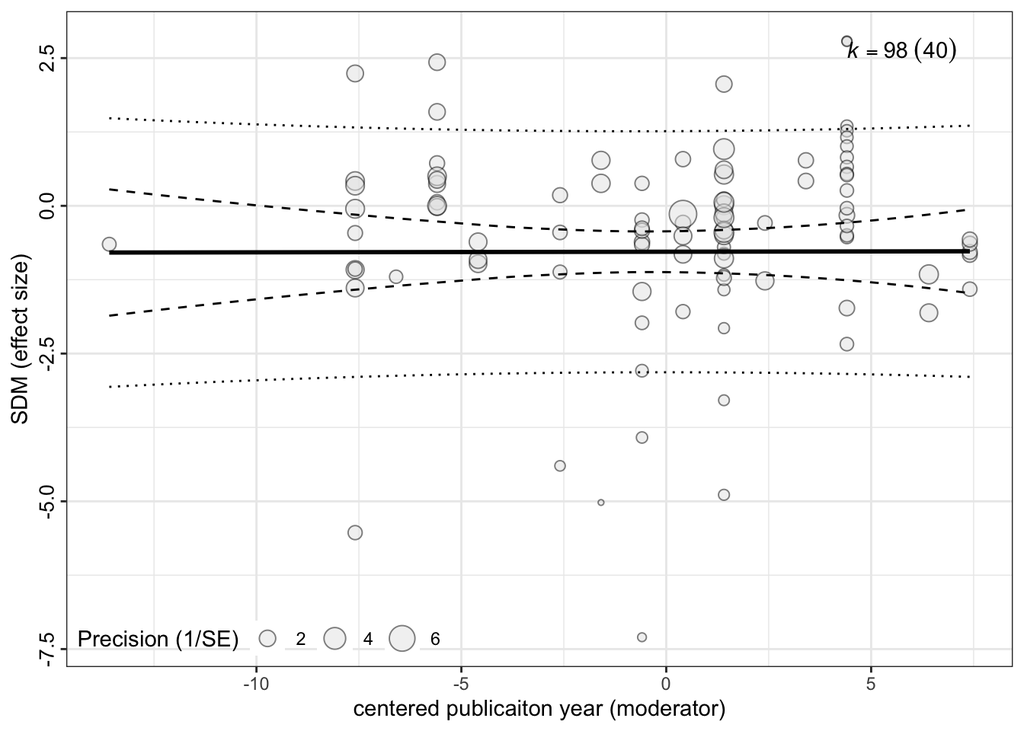

```r
bubble_plot(mr4_mod, mod = "cyear", group = "study_ID", g = TRUE,
            xlab = "centered publicaiton year (moderator)",
            ylab = "SDM (effect size)",
            legend.pos = "bottom.left")
```

#### 7.3.3.2 `blsmeta`

`blsmeta` can also be used to test the proposed four types of publication bias. Just add `se` and `cyear` as the moderators:

```r
dat$study_ID <- as.numeric(dat$study_ID)
fit_mr44 <- blsmeta(yi = smd,
                    vi = var.eff.size,
                    es_id = es_ID,
                    study_id = study_ID,
                    mods = ~ 1 + se + cyear,
                    mods_scale2 = ~ 1 + se + cyear,
                    data = dat)
#save
saveRDS(fit_mr44, here("Rdata", "fit_mr44.rds"))
```

We can see that `blsmeta` leads to similar parameter values as `brms`:

```r
# read in rds
fit_mr44 <- readRDS(here("Rdata", "fit_mr44.rds"))
print(fit_mr44)
## Model: Three-Level
## Studies2: 98
## Studies3: 40
## Samples: 20000 (4 chains)
## Location Formula: ~ 1 + se + cyear
## Scale2 Formula: ~ 1 + se + cyear
## Scale3 Formula: ~ 1
## Note: 'Scale' on standard deviation scale
## ------
## Scale2:
##             Post.mean Post.sd Cred.lb Cred.ub Rhat
## (Intercept)     -2.06    0.57   -3.33   -1.04 1.01
## se               1.65    0.65    0.01    2.73 1.00
## cyear           -0.19    0.07   -0.36   -0.09 1.01
##
## Scale3:
##               Post.mean Post.sd Cred.lb Cred.ub Rhat
## sd(Intercept)      0.62    0.12    0.41    0.88 1.00
##
## Location:
##             Post.mean Post.sd Cred.lb Cred.ub Rhat
## (Intercept)      0.08    0.29   -0.49    0.66 1.00
## se              -0.88    0.52   -1.89    0.15 1.00
## cyear           -0.04    0.04   -0.12    0.04 1.00
##
## ------
## Date: Fri Apr 18 16:06:36 2025
```

The slight differences are expected to be caused by the different priors and MCMC samplers used in `brms` and `blsmeta`.

# 8 Figure code

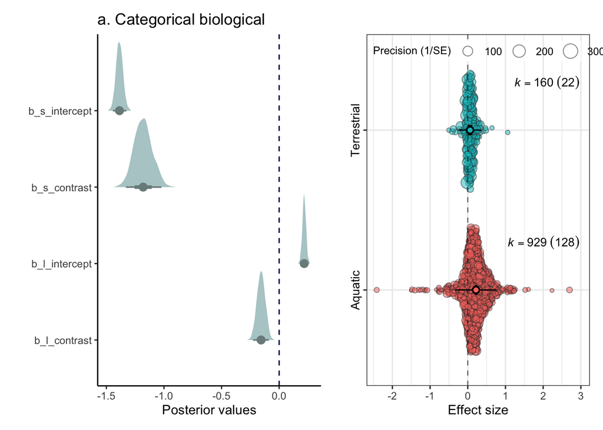

```r
# Function to visualize fixed effects (revised for fig)
visualize_fixed_effects <- function(model, title) {
  fixed_effect_vars <- get_variables_dynamic(model, "^b_")
  if (length(fixed_effect_vars) == 0) {
    message("No fixed effects found")
    return(NULL)
  }

  tryCatch({
    fixed_effects_samples <- model %>%
      spread_draws(!!!syms(fixed_effect_vars)) %>%
      pivot_longer(cols = all_of(fixed_effect_vars), names_to = ".variable", values_to = ".value") %>%
      mutate(.variable = rename_vars(.variable))

    ggplot(fixed_effects_samples, aes(x = .value, y = .variable)) +
      stat_halfeye(
        normalize = "xy",
        point_interval = "mean_qi",
        fill = "lightcyan3",
        color = "lightcyan4"
      ) +
      geom_vline(xintercept = 0, linetype = "dashed", color = "#005") +
      labs(title = title, y = "", x = "Posterior values") +
      theme_classic()
  }, error = function(e) {
    message("Error in visualize_fixed_effects: ", e$message)
    return(NULL)
  })
}


###########
# Example 1
###########

dat <- read.csv(here("data", "thermal.csv"))

# selecting varaibles we need
dat <- dat %>% select(dARR, Var_dARR, es_ID, population_ID, study_ID, exp_design, habitat)

# creating SE (sqrt(Var))
dat$si <- sqrt(dat$Var_dARR)

# creating a new variable (method) according to the oringal paper
dat$method <- ifelse(dat$exp_design == c("A", "B", "C"), "initial", "persisitent")

vcv <- diag(dat$Var_dARR)
rownames(vcv) <- dat$es_ID
colnames(vcv) <- dat$es_ID


# 4 plots

# plot 1

fit_mr1 <- readRDS(here("Rdata", "fit_mr1.rds"))
p1 <- visualize_fixed_effects(fit_mr1, title = "a. Categorical biological")



# plot 2

# using metafor and use heteroscad model
# see - Nakagawa S, Lagisz M, O'Dea RE, Pottier P, Rutkowska J, Senior AM, Yang Y, Noble DW. orchaRd 2.0: An R package for visualising meta-analyses with orchard plots.
mr1_mod <- rma.mv(yi = dARR,
                  V =  vcv,
                  mod = ~ habitat,
                  random = list(~1 | study_ID,
                                ~habitat | es_ID),
                  struct = "DIAG",
                  data = dat,
                  test = "t",
                  sparse = TRUE,
                  control=list(optimizer="optim", optmethod="Nelder-Mead")
)

p2 <- orchard_plot(mr1_mod, mod = "habitat",
             group = "study_ID",
             xlab = "Effect size",
             trunk.size = 0.5,
             branch.size = 4,
             legend.pos = "top.left",
             cb = FALSE
             #legend.pos = "none"
             ) +
  scale_colour_manual(values = rep("grey20",2))

p1 + p2
```

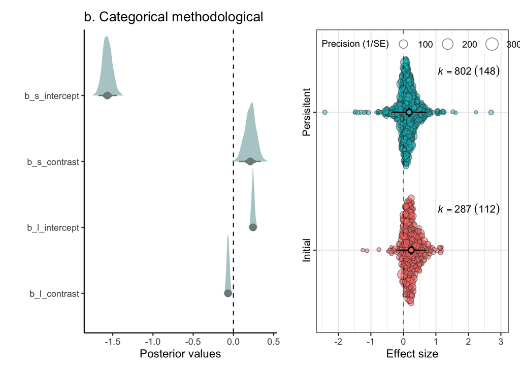

```r
# plot 3

fit_mr2 <- readRDS(here("Rdata", "fit_mr2.rds"))

p3 <- visualize_fixed_effects(fit_mr2, title = "b. Categorical methodological")

# plot 4

mr2_mod <- rma.mv(yi = dARR,
                  V =  vcv,
                  mod = ~ method,
                  random = list(~1 | study_ID,
                                ~method | es_ID),
                  struct = "DIAG",
                  data = dat,
                  test = "t",
                  sparse = TRUE,
                  control=list(optimizer="optim", optmethod="Nelder-Mead")
)

p4 <- orchard_plot(mr2_mod, mod = "method",
             group = "study_ID",
             xlab = "Effect size",
             trunk.size = 0.5,
             branch.size = 4,
             legend.pos = "top.left",
             cb = FALSE
             #legend.pos = "none"
             ) +
  scale_colour_manual(values = rep("grey20",2))

p3 + p4
```

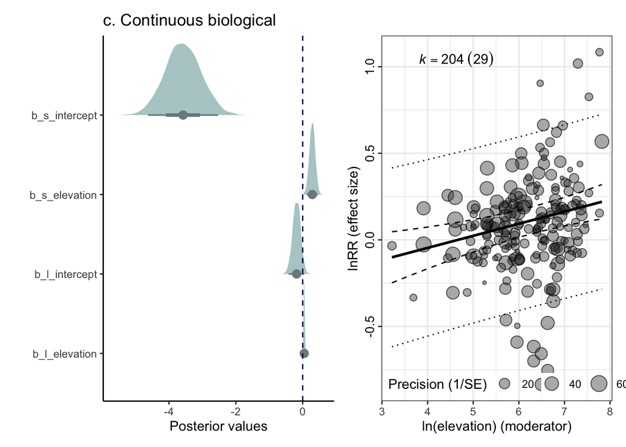

```r
############
# Example 2
############

dat <- read.csv(here("data", "elevation.csv"))
dim(dat)
## [1] 1294   24
# filter data LMA

dat <- dat %>% filter(trait == "Narea")

dim(dat)
## [1] 204  24

dat$study_ID <- as.factor(dat$Study_ID)
dat$es_ID <- as.factor(1:nrow(dat))

# using escalc use ROM

dat <- escalc(measure = "ROM",
              m1i = treatment,
              m2i = control,
              sd1i = sd_treatment,
              sd2i = sd_control,
              n1i = n_treatment,
              n2i = n_control,
              data = dat)


vcv <- diag(dat$vi)
rownames(vcv) <- dat$es_ID
colnames(vcv) <- dat$es_ID


# 2 plots

# plot 5

fit_mr3 <- readRDS(here("Rdata", "fit_mr3.rds"))

p5 <- visualize_fixed_effects(fit_mr3, title = "c. Continuous biological")

# plot 6

# using metafor and orchaRd
# see - Nakagawa S, Lagisz M, O'Dea RE, Pottier P, Rutkowska J, Senior AM, Yang Y, Noble DW. orchaRd 2.0: An R package for visualising meta-analyses with orchard plots.
mr3_mod <- rma.mv(yi = yi,
                  V =  vcv,
                  mod = ~ elevation_log,
                  random = list(~1 | study_ID,
                                ~1 | es_ID),
                  #struct = "DIAG",
                  data = dat,
                  test = "t",
                  sparse = TRUE,
                  control=list(optimizer="optim", optmethod="Nelder-Mead")
)

p6 <- bubble_plot(mr3_mod, mod = "elevation_log",
             group = "study_ID",
             g = TRUE,
             xlab = "ln(elevation) (moderator)",
             ylab = "lnRR (effect size)",
             legend.pos = "bottom.left",
             k.pos = "top.left") +
  geom_point(data = dat,
             aes(x = elevation_log, y = yi,
                 #fill = "green",
                 #colour = "green",
                 size = 1/sqrt(vi)), alpha = 0.3,
             #shape = 23
             ) #+
  # scale_color_discrete() +
  # scale_shape_manual(values = 21) +
  # scale_fill_manual(values = "#117733") +
  # scale_colour_manual(values = "grey20")

p5 + p6
```

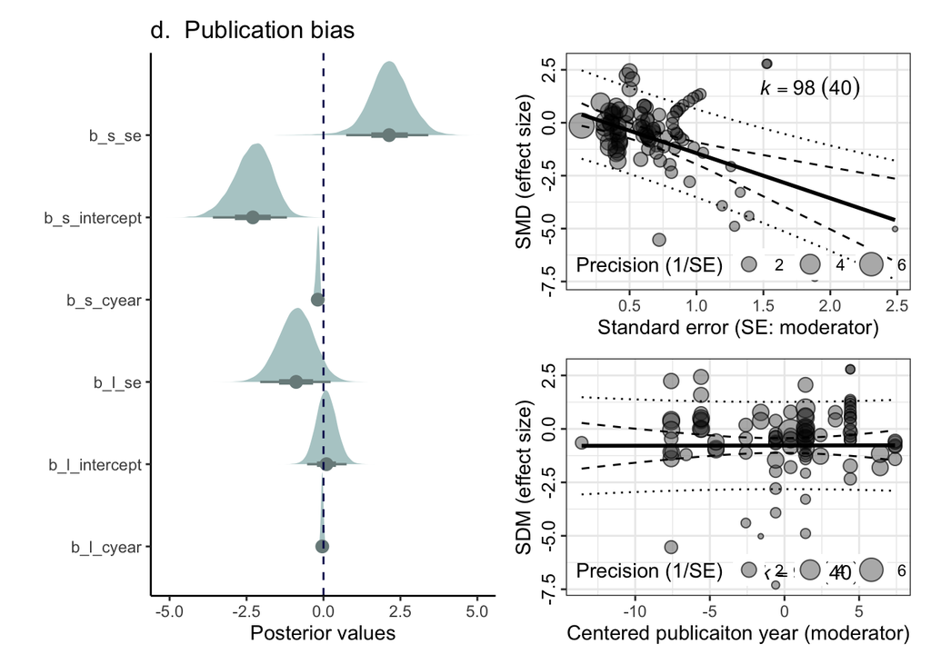

```r
############
# Example 3
############

dat <- read.csv(here("data", "seed.csv"))

dat$study_ID <- as.factor(dat$study)
dat$es_ID <- as.factor(1:nrow(dat))
dat$se <- sqrt(dat$var.eff.size) # SE (sampling error SD)
dat$smd <- dat$eff.size # effect isze
dat$cyear <- scale(dat$study.year, center = TRUE, scale = FALSE) # centred year


# selecting varaibles we need
dat <- dat %>% select(smd, var.eff.size, es_ID, study_ID, se, cyear)

dat$vi <- dat$var.eff.size
vcv <- diag(dat$var.eff.size)
rownames(vcv) <- dat$es_ID
colnames(vcv) <- dat$es_ID
# 3 plots

# plot 7

fit_mr4 <- readRDS(here("Rdata", "fit_mr4.rds"))

p7 <- visualize_fixed_effects(fit_mr4, title = "d.  Publication bias")


# plot 8

# using metafor and orchaRd

mr4_mod <- rma.mv(yi = smd,
                  V =  vcv,
                  mod = ~ se + cyear,
                  random = list(~1 | study_ID,
                                ~1 | es_ID),
                  #struct = "DIAG",
                  data = dat,
                  test = "t",
                  sparse = TRUE,
                  control=list(optimizer="optim", optmethod="Nelder-Mead")
)

p8 <- bubble_plot(mr4_mod, mod = "se", group = "study_ID", g = TRUE,
            xlab = "Standard error (SE: moderator)",
            ylab = "SMD (effect size)",
            legend.pos = "bottom.left",
            k.pos = "top.right") +
  geom_point(data = dat,
             aes(x = se, y =smd,
                 size = 1/sqrt(var.eff.size)), alpha = 0.3,
  )

# plot 9

p9 <- bubble_plot(mr4_mod, mod = "cyear", group = "study_ID", g = TRUE,
              xlab = "Centered publicaiton year (moderator)",
              ylab = "SDM (effect size)",
              legend.pos = "bottom.left",
              k.pos = "bottom.right") +
  geom_point(data = dat,
             aes(x = cyear, y = smd,
                 size = 1/sqrt(var.eff.size)), alpha = 0.3,
  )

p7 + (p8 / p9)
```

```r
### arranging

layout<- "
AABB
CCDD
EEFF
GGHH
GGII
"
# this is fig 4
#p1 + p2 + p3 + p4 + p5 + p6 + p7 + p8 + p9 + plot_layout(design = layout)
```

# 9 Software and package versions

**R version 4.4.2 (2024-10-31)**

**Platform:** aarch64-apple-darwin20

**locale:** en_US.UTF-8||en_US.UTF-8||en_US.UTF-8||C||en_US.UTF-8||en_US.UTF-8

**attached base packages:** *stats*, *graphics*, *grDevices*, *utils*, *datasets*, *methods* and *base*

**other attached packages:** *bayesplot(v.1.11.1)*, *ggtree(v.3.14.0)*, *ape(v.5.8-1)*, *blsmeta(v.0.1.0)*, *metafor(v.4.6-0)*, *numDeriv(v.2016.8-1.1)*, *metadat(v.1.2-0)*, *Matrix(v.1.7-0)*, *brms(v.2.22.0)*, *Rcpp(v.1.0.12)*, *pander(v.0.6.6)*, *orchaRd(v.2.0)*, *patchwork(v.1.3.0)*, *here(v.1.0.1)*, *tidybayes(v.3.0.7)*, *lubridate(v.1.9.4)*, *forcats(v.1.0.0)*, *stringr(v.1.5.1)*, *dplyr(v.1.1.4)*, *purrr(v.1.0.2)*, *readr(v.2.1.5)*, *tidyr(v.1.3.1)*, *tibble(v.3.2.1)*, *ggplot2(v.3.5.1)*, *tidyverse(v.2.0.0)* and *pacman(v.0.5.1)*

**loaded via a namespace (and not attached):** *gridExtra(v.2.3)*, *phangorn(v.2.12.1)*, *inline(v.0.3.21)*, *sandwich(v.3.1-0)*, *rlang(v.1.1.4)*, *magrittr(v.2.0.3)*, *multcomp(v.1.4-25)*, *matrixStats(v.1.5.0)*, *compiler(v.4.4.2)*, *mgcv(v.1.9-1)*, *loo(v.2.8.0)*, *reshape2(v.1.4.4)*, *vctrs(v.0.6.5)*, *quadprog(v.1.5-8)*, *bayeslincom(v.1.3.0)*, *pkgconfig(v.2.0.3)*, *arrayhelpers(v.1.1-0)*, *fastmap(v.1.2.0)*, *backports(v.1.5.0)*, *labeling(v.0.4.3)*, *utf8(v.1.2.4)*, *rmarkdown(v.2.29)*, *tzdb(v.0.4.0)*, *ggbeeswarm(v.0.7.2)*, *xfun(v.0.51)*, *aplot(v.0.2.5)*, *jsonlite(v.1.9.1)*, *parallel(v.4.4.2)*, *R6(v.2.5.1)*, *StanHeaders(v.2.32.10)*, *stringi(v.1.8.4)*, *rjags(v.4-16)*, *estimability(v.1.5.1)*, *rstan(v.2.32.7)*, *knitr(v.1.50)*, *zoo(v.1.8-12)*, *igraph(v.2.1.4)*, *splines(v.4.4.2)*, *timechange(v.0.3.0)*, *tidyselect(v.1.2.1)*, *rstudioapi(v.0.17.1)*, *abind(v.1.4-5)*, *yaml(v.2.3.10)*, *codetools(v.0.2-20)*, *pkgbuild(v.1.4.6)*, *plyr(v.1.8.9)*, *lattice(v.0.22-6)*, *treeio(v.1.30.0)*, *withr(v.3.0.0)*, *bridgesampling(v.1.1-2)*, *posterior(v.1.6.1)*, *coda(v.0.19-4.1)*, *evaluate(v.1.0.3)*, *gridGraphics(v.0.5-1)*, *survival(v.3.7-0)*, *RcppParallel(v.5.1.10)*, *ggdist(v.3.3.2)*, *pillar(v.1.9.0)*, *tensorA(v.0.36.2.1)*, *corrplot(v.0.95)*, *checkmate(v.2.3.2)*, *stats4(v.4.4.2)*, *ggfun(v.0.1.8)*, *distributional(v.0.5.0)*, *generics(v.0.1.3)*, *rprojroot(v.2.0.4)*, *mathjaxr(v.1.6-0)*, *hms(v.1.1.3)*, *rstantools(v.2.4.0)*, *munsell(v.0.5.1)*, *scales(v.1.3.0)*, *tidytree(v.0.4.6)*, *xtable(v.1.8-4)*, *glue(v.1.7.0)*, *emmeans(v.1.10.7)*, *lazyeval(v.0.2.2)*, *tools(v.4.4.2)*, *fs(v.1.6.5)*, *mvtnorm(v.1.2-5)*, *fastmatch(v.1.1-6)*, *grid(v.4.4.2)*, *QuickJSR(v.1.6.0)*, *colorspace(v.2.1-0)*, *nlme(v.3.1-165)*, *beeswarm(v.0.4.0)*, *vipor(v.0.4.7)*, *latex2exp(v.0.9.6)*, *cli(v.3.6.3)*, *fansi(v.1.0.6)*, *svUnit(v.1.0.6)*, *Brobdingnag(v.1.2-9)*, *gtable(v.0.3.5)*, *yulab.utils(v.0.2.0)*, *digest(v.0.6.37)*, *ggplotify(v.0.1.2)*, *TH.data(v.1.1-2)*, *htmlwidgets(v.1.6.4)*, *farver(v.2.1.2)*, *htmltools(v.0.5.8.1)*, *lifecycle(v.1.0.4)* and *MASS(v.7.3-61)*